# DATA 606 Week 2 Homework

Henry Otuadinma

4 February 2019

### 2.6 Dice rolls.

If you roll a pair of fair dice, what is the probability of

1. getting a sum of 1?

Answer: The probability of getting a sum of 1 = 1/36

2. getting a sum of 5?

Answer:

The probability of getting a sum of 5 = 4/36 = 1/9

3. getting a sum of 12?

The probability of getting a sum of 12 = 1/36

### 2.8 Poverty and language.

The American Community Survey is an ongoing survey that provides data every year to give communities the current information they need to plan investments and services. The 2010 American Community Survey estimates that 14.6% of Americans live below the poverty line, 20.7% speak a language other than English (foreign language) at home, and 4.2% fall into both categories.

### (a) Are living below the poverty line and speaking a foreign language at home disjoint?

Answer: No, they are not disjoint

2. Draw a Venn diagram summarizing the variables and their associated probabilities.

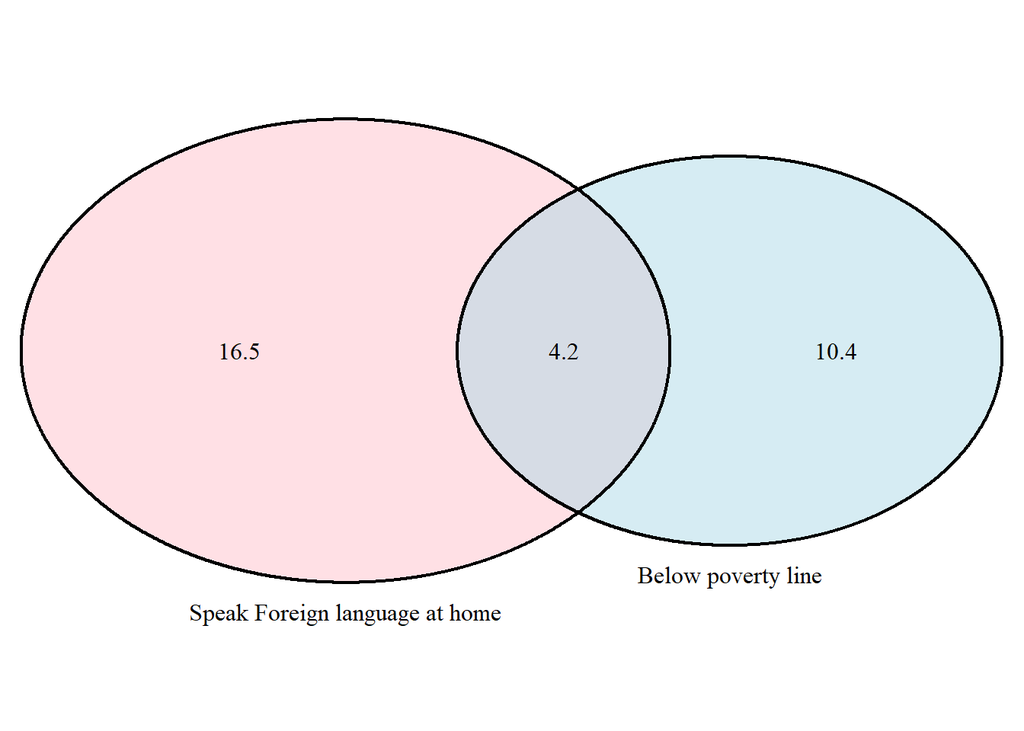

```
## (polygon[GRID.polygon.11], polygon[GRID.polygon.12], polygon[GRID.polygon.13], polygon[GRID.polygon.14], text[GRID.text.15], text[GRID.text.16], text[GRID.text.17], text[GRID.text.18], text[GRID.text.19])
```

```r
# source: https://rstudio-pubs-static.s3.amazonaws.com/13301_6641d73cfac741a59c0a851feb99e98b.html

grid.newpage()
draw.pairwise.venn(14.6, 20.7, 4.2, category = c("Below poverty line", "Speak Foreign language at home"), fill = c("light blue", "pink"), alpha = rep(0.5, 2), cat.pos = c(0,
    0), cat.dist = rep(0.025, 2))
```

3. What percent of Americans live below the poverty line and only speak English at home?

Answer: 10.4%

4. What percent of Americans live below the poverty line or speak a foreign language at home?

Answer: percent of Americans live below the poverty line or speak a foreign language at home = 16.5 + 4.2 + 10.4 = 31.1%

5. What percent of Americans live above the poverty line and only speak English at home?

Answer: 100 - 31.1 = 68.9%

6. Is the event that someone lives below the poverty line independent of the event that the person speaks a foreign language at home?

Answer:

P(Belowe Pverty line) = 14.6 P(Foreign Language at home) = 20.7

P(Below Poverty line) * P(Foreign Language at home) = 14.6/100 * 20.7/100 = 0.146 * 0.207 = 0.03022 * 100 = 3.022% Since 3.022% is not equal to 4.2%, it implies that the two events are not independent

### 2.20 Assortative mating.

Assortative mating is a nonrandom mating pattern where individuals with similar genotypes and/or phenotypes mate with one another more frequently than what would be expected under a random mating pattern. Researchers studying this topic collected data on eye colors of 204 Scandinavian men and their female partners. The table below summarizes the results. For simplicity, we only include heterosexual relationships in this exercise.

```r
male <- c('Blue', 'Brown', 'Green')
Brown <- c(23, 23, 9)
Blue <- c(78, 19, 11)
Green <- c(13, 12, 16)
df <- data.frame(Blue, Brown, Green, row.names = male)
df$Totals <- apply(df, 1, sum)
df['Total',] <- colSums(df)

kable(df, align = "c") %>%
  column_spec(1:4, bold = T, color = "#000")%>%
  row_spec(1:4, bold = T, color = "#000")%>%
  kable_styling("striped", full_width = T) %>%
  add_header_above(c(" ", "Partner (female)" = 4))
```

|  | Partner (female) Blue | Partner (female) Brown | Partner (female) Green | Partner (female) Totals |
| --- | --- | --- | --- | --- |
| Blue | 78 | 23 | 13 | 114 |
| Brown | 19 | 23 | 12 | 54 |
| Green | 11 | 9 | 16 | 36 |
| Total | 108 | 55 | 41 | 204 |

1. What is the probability that a randomly chosen male respondent or his partner has blue eyes?

```r
p_male_blue <- df['Blue', 'Totals']/df['Total', 'Totals']

p_female_blue <- df['Total', 'Blue']/df['Total', 'Totals']

p_blue_blue <- df['Blue', 'Blue']/df['Total', 'Totals']

P_male_female_blue <- (p_male_blue + p_female_blue) - p_blue_blue # This is to avoid p_blue_blue from being counted twice

cat('The probability that male respondent or his partner has blue eyes is: ', P_male_female_blue)
```

```
## The probability that male respondent or his partner has blue eyes is:  0.7058824
```

2. What is the probability that a randomly chosen male respondent with blue eyes has a partner with blue eyes?

```r
p_blue_blue <- df['Blue', 'Blue']/df['Blue', 'Totals']

cat('The probability that both male and his partner have blue eyes is: ', p_blue_blue)
```

```
## The probability that both male and his partner have blue eyes is:  0.6842105
```

3. What is the probability that a randomly chosen male respondent with brown eyes has a partner with blue eyes?

```r
p_male_brown_female_blue <- df['Brown', 'Blue']/df['Brown', 'Totals']

cat('The probability that male with Brown eyes has a partner with Blue eyes: ', p_male_brown_female_blue)
```

```
## The probability that male with Brown eyes has a partner with Blue eyes:  0.3518519
```

What about the probability of a randomly chosen male respondent with green eyes having a partner with blue eyes?

```r
p_male_green_female_blue <- df['Green', 'Blue']/df['Green', 'Totals']

cat('The probability that male with Green eyes has a partner with Blue eyes: ', p_male_green_female_blue)
```

```
## The probability that male with Green eyes has a partner with Blue eyes:  0.3055556
```

4. Does it appear that the eye colors of male respondents and their partners are independent? Explain your reasoning.

```r
all.equal(p_blue_blue, p_female_blue)
```

```
## [1] "Mean relative difference: 0.2262443"
```

```r
identical(p_blue_blue, p_female_blue)
```

```
## [1] FALSE
```

```r
cat('Since ', p_blue_blue, 'and ', p_female_blue, ' are not equal, the eye colors appear to be dependent')
```

```
## Since  0.6842105 and  0.5294118  are not equal, the eye colors appear to be dependent
```

### 2.30 Books on a bookshelf.

The table below shows the distribution of books on a bookcase based on whether they are nonfiction or fiction and hardcover or paperback. Format

```r
books <- c('Fiction', 'Nonfiction')
Hardcover <- c(13, 15)
Paperback <- c(59, 8)
df1 <- data.frame(Hardcover, Paperback, row.names = books)
df1$Totals <- apply(df1, 1, sum)
df1['Total', ] <- colSums(df1)

kable(df1, align = "c") %>%
  column_spec(1:4, bold = T, color = "#000")%>%
  row_spec(1:3, bold = T, color = "#000")%>%
  kable_styling("striped", full_width = T) %>%
  add_header_above(c(" ", "Format" = 3))
```

|  | Format Hardcover | Format Paperback | Format Totals |
| --- | --- | --- | --- |
| Fiction | 13 | 59 | 72 |
| Nonfiction | 15 | 8 | 23 |
| Total | 28 | 67 | 95 |

1. Find the probability of drawing a hardcover book first then a paperback fiction book second when drawing without replacement.

```r
p_hardcover_fiction <- df1['Total', 'Hardcover']/df1['Total', 'Totals']

p_paperback_fiction <- (df1['Fiction', 'Paperback'])/(df1['Total', 'Totals'] - 1)

p <- p_hardcover_fiction * p_paperback_fiction

cat('The probability of these events is:', round(p, 2))
```

```
## The probability of these events is: 0.18
```

2. Determine the probability of drawing a fiction book first and then a hardcover book second, when drawing without replacement.

Answer:

This can occur two ways => First, a paperback fiction and a hardcover book were picked

```r
p_paperback_fiction <- df1['Fiction', 'Paperback']/df1['Total', 'Totals']
p_hardcover1 <- df1['Total', 'Hardcover']/(df1['Total', 'Totals'] - 1)

p1 <- p_hardcover1 * p_paperback_fiction

cat('The probability of these events is:', round(p1, 2))
```

```
## The probability of these events is: 0.18
```

Second, a hardcover fiction and a hardcover book were picked. This will reduce the number of hardcover books by 1

```r
p_hardcover_fiction <- df1['Fiction', 'Hardcover']/(df1['Total', 'Totals'])
p_hardcover2 <- (df1['Total', 'Hardcover'] - 1)/(df1['Total', 'Totals'] - 1)

p2 <- p_hardcover2 * p_hardcover_fiction

cat('The probability of these events is:', round(p2, 2))
```

```
## The probability of these events is: 0.04
```

```r
P <- p1 + p2
cat('The probability of both events is:', round(P, 4))
```

```
## The probability of both events is: 0.2243
```

3. Calculate the probability of the scenario in part (b), except this time complete the calculations under the scenario where the first book is placed back on the bookcase before randomly drawing the second book.

```r
p_hardcover_fiction1 <- df1['Fiction', 'Totals']/(df1['Total', 'Totals'])
p_hardcover3 <- (df1['Total', 'Hardcover'])/(df1['Total', 'Totals'])

p3 <- p_hardcover3 * p_hardcover_fiction1

cat('The probability of these events is:', round(p3, 4))
```

```
## The probability of these events is: 0.2234
```

4. The final answers to parts (b) and (c) are very similar. Explain why this is the case.

Answer: Since only one book is either removed or replaced, the effect is not much on the entire number of books => the sampling size is much smaller than the entire population

### 2.38 Baggage fees.

An airline charges the following baggage fees: $25 for the first bag and $35 for the second. Suppose 54% of passengers have no checked luggage, 34% have one piece of checked luggage and 12% have two pieces. We suppose a negligible portion of people check more than two bags.

1. Build a probability model, compute the average revenue per passenger, and compute the corresponding standard deviation.

```r
baggageFees <- c(0, 25, 35)
probCheck <- c(0.54, 0.34, 0.12)
baggages <- c(0, 1, 2)
fees <- data.frame(baggageFees, probCheck, baggages)
fees$charged <- fees$baggageFees * fees$probCheck
avRevenuePerPassenger <- sum(fees$charged)

paste0 ('The average revenue per passenger is $', avRevenuePerPassenger)
```

```
## [1] "The average revenue per passenger is $12.7"
```

```r
baggageFees <- c(0, 25, 35)
probCheck <- c(0.54, 0.34, 0.12)
baggages <- c(0, 1, 2)
fees$varPerPersenger <- (fees$baggageFees - avRevenuePerPassenger)^2 * fees$probCheck

stdPerPassenger <- sqrt(sum(fees$varPerPersenger))

paste0('The standard deviation per passenger is ', round(stdPerPassenger, 2))
```

```
## [1] "The standard deviation per passenger is 14.08"
```

2. About how much revenue should the airline expect for a flight of 120 passengers? With what standard deviation? Note any assumptions you make and if you think they are justified.

```r
expectedRevenue <- 120 * avRevenuePerPassenger
paste0('Expected revenue for a flight of 120 passengers is $', round(expectedRevenue, 2))
```

```
## [1] "Expected revenue for a flight of 120 passengers is $1524"
```

```r
std120 <- sqrt(120*stdPerPassenger^2)
paste0('The standard deviation will be: ', round(std120, 2))
```

```
## [1] "The standard deviation will be: 154.22"
```

### 2.44 Income and gender.

The relative frequency table below displays the distribution of annual total personal income (in 2009 inflation-adjusted dollars) for a representative sample of 96,420,486 Americans. These data come from the American Community Survey for 2005-2009. This sample is comprised of 59% males and 41% females.

```r
incomeGroup <- c("$1 - $9,999 or less", "$10,000 - $14,999", "$15,000 - $24,999",
          "$25,000 - $34,999", "$35,000 - $49,999", "$50,000 - $64,999",
          "$65,000 - $74,999", "$75,000 - $99,999", "$100,000 or more")
incomeGroupPercent <- c(.022, .047, .158, .183, .212, .139, .058, .084, 0.097)

incomes <- data.frame(incomeGroup, incomeGroupPercent)

 # The line below prevents ggplot from reordering the graph.
incomes$incomeGroup <- factor(incomes$incomeGroup, levels = incomes$incomeGroup)

kable(incomes, align = "c") %>%
  column_spec(1:2, bold = T, color = "#000")%>%
  row_spec(1:9, bold = T, color = "#000")%>%
  kable_styling("striped", full_width = T)
```

| incomeGroup | incomeGroupPercent |
| --- | --- |
| $1 - $9,999 or less | 0.022 |
| $10,000 - $14,999 | 0.047 |
| $15,000 - $24,999 | 0.158 |
| $25,000 - $34,999 | 0.183 |
| $35,000 - $49,999 | 0.212 |
| $50,000 - $64,999 | 0.139 |
| $65,000 - $74,999 | 0.058 |
| $75,000 - $99,999 | 0.084 |
| $100,000 or more | 0.097 |

1. Describe the distribution of total personal income.

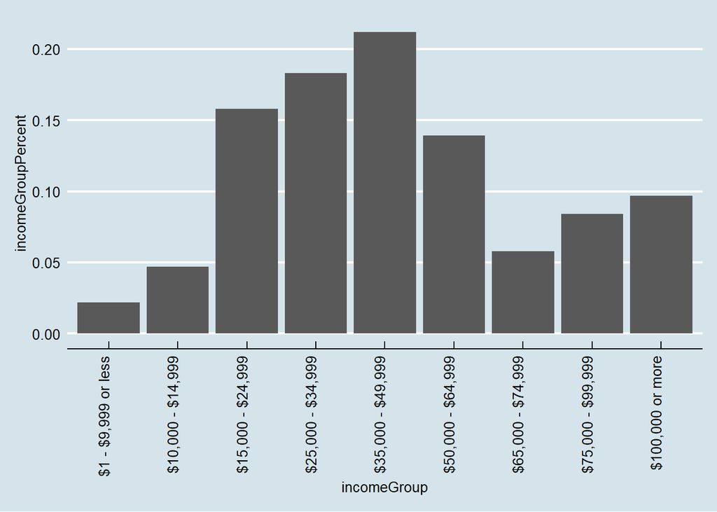

```r
ggplot(data = incomes, aes(incomeGroup, incomeGroupPercent)) + geom_bar(stat = "identity")  + theme_economist() + theme(axis.text.x = element_text(angle = 90, hjust = 1))
```

2. What is the probability that a randomly chosen US resident makes less than $50,000 per year?

```r
earnBelow50 <- sum(incomes[1:5, 2])
paste0('The probability that the person earns below $50, 000 is: ', earnBelow50)
```

```
## [1] "The probability that the person earns below $50, 000 is: 0.622"
```

3. What is the probability that a randomly chosen US resident makes less than $50,000 per year and is female? Note any assumptions you make.

```r
paste0('The probability that the person earns below $50, 000 and is a female is: ', earnBelow50 * 0.41)
```

```
## [1] "The probability that the person earns below $50, 000 and is a female is: 0.25502"
```

Assumptions: Income and gender are independent variables and there might be a sampling bias that made the distribution to present 41% of the respondents to be female instead of the sampling being divided in the middle (50% females, 50% males)

4. The same data source indicates that 71.8% of females make less than $50,000 per year. Use this value to determine whether or not the assumption you made in part (c) is valid.

```r
paste0('The probability that the person earns below $50, 000 and is a female is: ', 0.41 * 0.718)
```

```
## [1] "The probability that the person earns below $50, 000 and is a female is: 0.29438"
```

Part (d) states the actual distribution of females who make less than $50, 000 peer year, while part (c) considers the event of a randomly selected respondent being a female and earns less than $50, 000 per year. So from part (d), out of the 41% that are females, 71.8% of them earn less than $50, 000 per year.

The change in the calculated chances is approximately 4% which is very small and indicates that the assumption in part c above is not valid. Women actually earn less.